# Heart attack dataset modeling analysis

Tales Gomes

25/01/2022

## About this dataset

- Age: Age of the patient
- Sex: Sex of the patient
- exng: exercise induced angina (1 = yes; 0 = no)
- ca: number of major vessels (0-3)
- cp: Chest Pain type
  - Value 1: typical angina
  - Value 2: atypical angina
  - Value 3: non-anginal pain
  - Value 4: asymptomatic
- trtbps: resting blood pressure (in mm Hg)
- chol: cholestoral in mg/dl fetched via BMI sensor
- fbs: (fasting blood sugar > 120 mg/dl) (1 = true; 0 = false)
- rest_ecg: resting electrocardiographic results
  - Value 0: normal
  - Value 1: having ST-T wave abnormality (T wave inversions and/or ST elevation or depression of > 0.05 mV)
  - Value 2: showing probable or definite left ventricular hypertrophy by Estes’ criteria
- thalach: maximum heart rate achieved
- target: 0= less chance of heart attack 1= more chance of heart attack

## Importing the data

The Data can be aquired in the [kaggle site](https://www.kaggle.com/rashikrahmanpritom/heart-attack-analysis-prediction-dataset).

```r
heart_df <- read_csv("heart.csv")
```

### fisrt look in the data

Now that we have the data loaded we can use glimpse to see it.

```r
glimpse(heart_df)
```

```
## Rows: 303
## Columns: 14
## $ age      <dbl> 63, 37, 41, 56, 57, 57, 56, 44, 52, 57, 54, 48, 49, 64, 58, 5…
## $ sex      <dbl> 1, 1, 0, 1, 0, 1, 0, 1, 1, 1, 1, 0, 1, 1, 0, 0, 0, 0, 1, 0, 1…
## $ cp       <dbl> 3, 2, 1, 1, 0, 0, 1, 1, 2, 2, 0, 2, 1, 3, 3, 2, 2, 3, 0, 3, 0…
## $ trtbps   <dbl> 145, 130, 130, 120, 120, 140, 140, 120, 172, 150, 140, 130, 1…
## $ chol     <dbl> 233, 250, 204, 236, 354, 192, 294, 263, 199, 168, 239, 275, 2…
## $ fbs      <dbl> 1, 0, 0, 0, 0, 0, 0, 0, 1, 0, 0, 0, 0, 0, 1, 0, 0, 0, 0, 0, 0…
## $ restecg  <dbl> 0, 1, 0, 1, 1, 1, 0, 1, 1, 1, 1, 1, 1, 0, 0, 1, 1, 1, 1, 1, 1…
## $ thalachh <dbl> 150, 187, 172, 178, 163, 148, 153, 173, 162, 174, 160, 139, 1…
## $ exng     <dbl> 0, 0, 0, 0, 1, 0, 0, 0, 0, 0, 0, 0, 0, 1, 0, 0, 0, 0, 0, 0, 0…
## $ oldpeak  <dbl> 2.3, 3.5, 1.4, 0.8, 0.6, 0.4, 1.3, 0.0, 0.5, 1.6, 1.2, 0.2, 0…
## $ slp      <dbl> 0, 0, 2, 2, 2, 1, 1, 2, 2, 2, 2, 2, 2, 1, 2, 1, 2, 0, 2, 2, 1…
## $ caa      <dbl> 0, 0, 0, 0, 0, 0, 0, 0, 0, 0, 0, 0, 0, 0, 0, 0, 0, 0, 0, 2, 0…
## $ thall    <dbl> 1, 2, 2, 2, 2, 1, 2, 3, 3, 2, 2, 2, 2, 2, 2, 2, 2, 2, 2, 2, 3…
## $ output   <dbl> 1, 1, 1, 1, 1, 1, 1, 1, 1, 1, 1, 1, 1, 1, 1, 1, 1, 1, 1, 1, 1…
```

## Data Manipulation

Wen can see that R imported all the data as numeric, but as we know that some variable are categorical. Than, to facilitate the manipulation wen can store that information in two variables.

```r
#categorical variables
factor_vars <- c("sex", "cp", "fbs",
                 "restecg", "exng",
                 "exng","slp", "caa",
                 "thall", "output")

#numeric variables
numeric_vars <- c("age", "trtbps", "chol",
                  "thalachh", "oldpeak" )
```

First thing wen can do is verify if that is some NAs in the data.

```r
apply(heart_df, 2, function(x){sum(is.na(x))})
```

```
##      age      sex       cp   trtbps     chol      fbs  restecg thalachh
##        0        0        0        0        0        0        0        0
##     exng  oldpeak      slp      caa    thall   output
##        0        0        0        0        0        0
```

Now that we saw that wen don’t have NAs, wen can convert the catorical vriable to factos.

```r
heart_data <- heart_df %>%
    #Transforming categorical variable to factors
    mutate_at(factor_vars, as_factor) %>%
    # Reordering the columns to better visualizate the data
    relocate(where(is.numeric), .before = where(is.factor)) #%>%
```

We can see how the dataset is with glimpse.

```r
glimpse(heart_data)
```

```
## Rows: 303
## Columns: 14
## $ age      <dbl> 63, 37, 41, 56, 57, 57, 56, 44, 52, 57, 54, 48, 49, 64, 58, 5…
## $ trtbps   <dbl> 145, 130, 130, 120, 120, 140, 140, 120, 172, 150, 140, 130, 1…
## $ chol     <dbl> 233, 250, 204, 236, 354, 192, 294, 263, 199, 168, 239, 275, 2…
## $ thalachh <dbl> 150, 187, 172, 178, 163, 148, 153, 173, 162, 174, 160, 139, 1…
## $ oldpeak  <dbl> 2.3, 3.5, 1.4, 0.8, 0.6, 0.4, 1.3, 0.0, 0.5, 1.6, 1.2, 0.2, 0…
## $ sex      <fct> 1, 1, 0, 1, 0, 1, 0, 1, 1, 1, 1, 0, 1, 1, 0, 0, 0, 0, 1, 0, 1…
## $ cp       <fct> 3, 2, 1, 1, 0, 0, 1, 1, 2, 2, 0, 2, 1, 3, 3, 2, 2, 3, 0, 3, 0…
## $ fbs      <fct> 1, 0, 0, 0, 0, 0, 0, 0, 1, 0, 0, 0, 0, 0, 1, 0, 0, 0, 0, 0, 0…
## $ restecg  <fct> 0, 1, 0, 1, 1, 1, 0, 1, 1, 1, 1, 1, 1, 0, 0, 1, 1, 1, 1, 1, 1…
## $ exng     <fct> 0, 0, 0, 0, 1, 0, 0, 0, 0, 0, 0, 0, 0, 1, 0, 0, 0, 0, 0, 0, 0…
## $ slp      <fct> 0, 0, 2, 2, 2, 1, 1, 2, 2, 2, 2, 2, 2, 1, 2, 1, 2, 0, 2, 2, 1…
## $ caa      <fct> 0, 0, 0, 0, 0, 0, 0, 0, 0, 0, 0, 0, 0, 0, 0, 0, 0, 0, 0, 2, 0…
## $ thall    <fct> 1, 2, 2, 2, 2, 1, 2, 3, 3, 2, 2, 2, 2, 2, 2, 2, 2, 2, 2, 2, 3…
## $ output   <fct> 1, 1, 1, 1, 1, 1, 1, 1, 1, 1, 1, 1, 1, 1, 1, 1, 1, 1, 1, 1, 1…
```

### Manipuling the numerical variable

First we can calculate the mean and standard deviation of the data to see if we need to scale the data.

```r
summary(heart_data[, numeric_vars])
```

```
##       age            trtbps           chol          thalachh        oldpeak
##  Min.   :29.00   Min.   : 94.0   Min.   :126.0   Min.   : 71.0   Min.   :0.00
##  1st Qu.:47.50   1st Qu.:120.0   1st Qu.:211.0   1st Qu.:133.5   1st Qu.:0.00
##  Median :55.00   Median :130.0   Median :240.0   Median :153.0   Median :0.80
##  Mean   :54.37   Mean   :131.6   Mean   :246.3   Mean   :149.6   Mean   :1.04
##  3rd Qu.:61.00   3rd Qu.:140.0   3rd Qu.:274.5   3rd Qu.:166.0   3rd Qu.:1.60
##  Max.   :77.00   Max.   :200.0   Max.   :564.0   Max.   :202.0   Max.   :6.20
```

```r
apply(heart_data[, numeric_vars], 2, sd)
```

```
##       age    trtbps      chol  thalachh   oldpeak
##  9.082101 17.538143 51.830751 22.905161  1.161075
```

Now let’s plot the data distribution

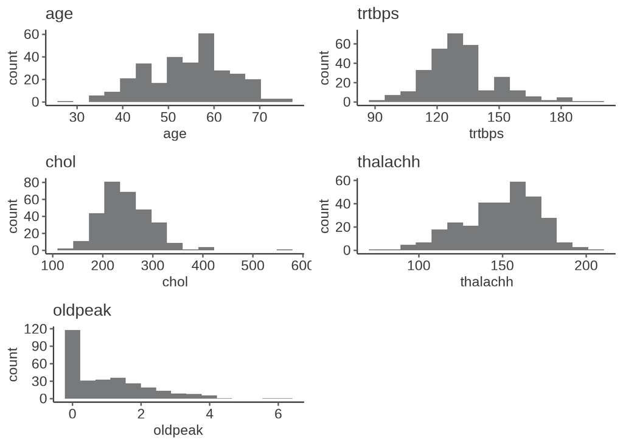

```r
#Setting ggplot theme
theme_set(theme_pubr())

#Function to Plot the histogram
plot_histogram <- function(data, col){
  ggplot(data, aes_string(col)) +
    geom_histogram(bins=15) +
    ggtitle(col)
}


# Creating the histogram of the numeric variable
plot1 <- plot_histogram(heart_data, numeric_vars[1])
plot2 <- plot_histogram(heart_data, numeric_vars[2])
plot3 <- plot_histogram(heart_data, numeric_vars[3])
plot4 <- plot_histogram(heart_data, numeric_vars[4])
plot5 <- plot_histogram(heart_data, numeric_vars[5])


#merging the plot in one space
figure <- ggarrange(plot1, plot2, plot3, plot4, plot5,
                    ncol = 2, nrow = 3)
figure
```

As we can see some variables are on different scales so we will perform the normalization of the data.

```r
# #scale
# heart_data <- heart_data %>%
#     mutate_if(is.numeric, ~(scale(.) %>% as.vector))



#Normalise function
normalize <- function(x){((x-min(x)) /(max(x)-min(x)))}


heart_data <- heart_data %>%
    mutate_if(is.numeric, ~(normalize(.) %>% as.vector))
```

One last verification to see if we don’t introduced some NAs in the data.

```r
#Verify if has NA
apply(heart_data, 2, function(x){sum(is.na(x))})
```

```
##      age   trtbps     chol thalachh  oldpeak      sex       cp      fbs
##        0        0        0        0        0        0        0        0
##  restecg     exng      slp      caa    thall   output
##        0        0        0        0        0        0
```

Before starting modeling, we have to verify if the data is balanced.

```r
# Se the difference in numbers of cases with 0 and 1
heart_data %>%
count(output)
```

```
## # A tibble: 2 × 2
##   output     n
##   <fct>  <int>
## 1 0        138
## 2 1        165
```

```r
#Verify the percentage of case of heart attack
mean(heart_data$output == 1)
```

```
## [1] 0.5445545
```

## Data modeling

### Base Model

Now that our data is balanced, proper marked as numerical and categorical and normalized, we can train our first model. As a base model, we will use the logistic model with all the variable of the data set.

#### Split the data

First, we will split the data in train and test. For that, we used dplyr package.

```r
set.seed(7325)   # set seed to ensure you always have same random numbers generated

heart_data <- heart_data %>% mutate(id = row_number())


# We seareted the data in 70% traning and 20% test
#Create training set
training_set <- heart_data %>% slice_sample(prop = .80)
#Create test set
test_set  <- anti_join(heart_data, training_set, by = 'id')

# Drping the id column
training_set <- training_set %>%
  select(-id)
# Drping the id column
test_set <- test_set %>%
  select(-id)
# Drping the id column
heart_data <- heart_data %>%
   select(-id)
```

#### Traning the model

Now with the splited data e can train the model.

```r
base_model <- glm(output ~ ., data = training_set, family = binomial)

summary(base_model)
```

```
##
## Call:
## glm(formula = output ~ ., family = binomial, data = training_set)
##
## Deviance Residuals:
##     Min       1Q   Median       3Q      Max
## -2.9510  -0.3108   0.1166   0.4571   3.0602
##
## Coefficients:
##             Estimate Std. Error z value Pr(>|z|)
## (Intercept) -0.33963    3.67946  -0.092 0.926457
## age          1.62458    1.37038   1.185 0.235823
## trtbps      -2.87173    1.40111  -2.050 0.040403 *
## chol        -1.88148    2.06866  -0.910 0.363078
## thalachh     1.19894    1.66429   0.720 0.471283
## oldpeak     -1.26533    1.65789  -0.763 0.445332
## sex1        -1.72463    0.62718  -2.750 0.005962 **
## cp1          1.23707    0.66761   1.853 0.063883 .
## cp2          2.39112    0.62800   3.807 0.000140 ***
## cp3          2.49939    0.80474   3.106 0.001897 **
## fbs1         0.18324    0.67945   0.270 0.787401
## restecg1    -0.02946    0.45585  -0.065 0.948475
## restecg2    -1.45978    2.96394  -0.493 0.622357
## exng1       -0.50387    0.50036  -1.007 0.313924
## slp1        -0.67339    0.86815  -0.776 0.437945
## slp2         1.03288    0.94188   1.097 0.272809
## caa1        -2.45455    0.58308  -4.210 2.56e-05 ***
## caa2        -4.09296    1.09787  -3.728 0.000193 ***
## caa3        -3.23687    1.20703  -2.682 0.007325 **
## caa4         1.28017    1.74665   0.733 0.463601
## thall1       2.45427    3.45081   0.711 0.476950
## thall2       2.54240    3.36940   0.755 0.450516
## thall3       1.10721    3.37603   0.328 0.742939
## ---
## Signif. codes:  0 '***' 0.001 '**' 0.01 '*' 0.05 '.' 0.1 ' ' 1
##
## (Dispersion parameter for binomial family taken to be 1)
##
##     Null deviance: 331.24  on 241  degrees of freedom
## Residual deviance: 145.64  on 219  degrees of freedom
## AIC: 191.64
##
## Number of Fisher Scoring iterations: 6
```

#### Predicting and Accuracy

After training the model we can do the predictions.

```r
#variable to store predictions across all models
predictions <- 0

# Predicting the base model
predictions$base_prob <- predict(base_model, test_set, type = "response")

# Predict a heart attack if probability of output is greater than average
predictions$base_pred <- ifelse(predictions$base_prob > 0.5, 1, 0)
```

Lets see how good is the model based on the predictions.

```r
# Calculate the total model's accuracy
print("Accuracy total model")
```

```
## [1] "Accuracy total model"
```

```r
mean(predictions$base_pred  == test_set$output)
```

```
## [1] 0.852459
```

At the first version of our model we achieved a 85% of Accuracy. Now lets see the confusion matrix.

```r
#Confusion matrix total model
print("Confusion matrix full model")
```

```
## [1] "Confusion matrix full model"
```

```r
caret::confusionMatrix(table(predictions$base_pred , test_set$output))
```

```
## Confusion Matrix and Statistics
##
##
##      0  1
##   0 30  6
##   1  3 22
##
##                Accuracy : 0.8525
##                  95% CI : (0.7383, 0.9302)
##     No Information Rate : 0.541
##     P-Value [Acc > NIR] : 2.6e-07
##
##                   Kappa : 0.7005
##
##  Mcnemar's Test P-Value : 0.505
##
##             Sensitivity : 0.9091
##             Specificity : 0.7857
##          Pos Pred Value : 0.8333
##          Neg Pred Value : 0.8800
##              Prevalence : 0.5410
##          Detection Rate : 0.4918
##    Detection Prevalence : 0.5902
##       Balanced Accuracy : 0.8474
##
##        'Positive' Class : 0
##
```

Let’s plot the Roc courve of the model

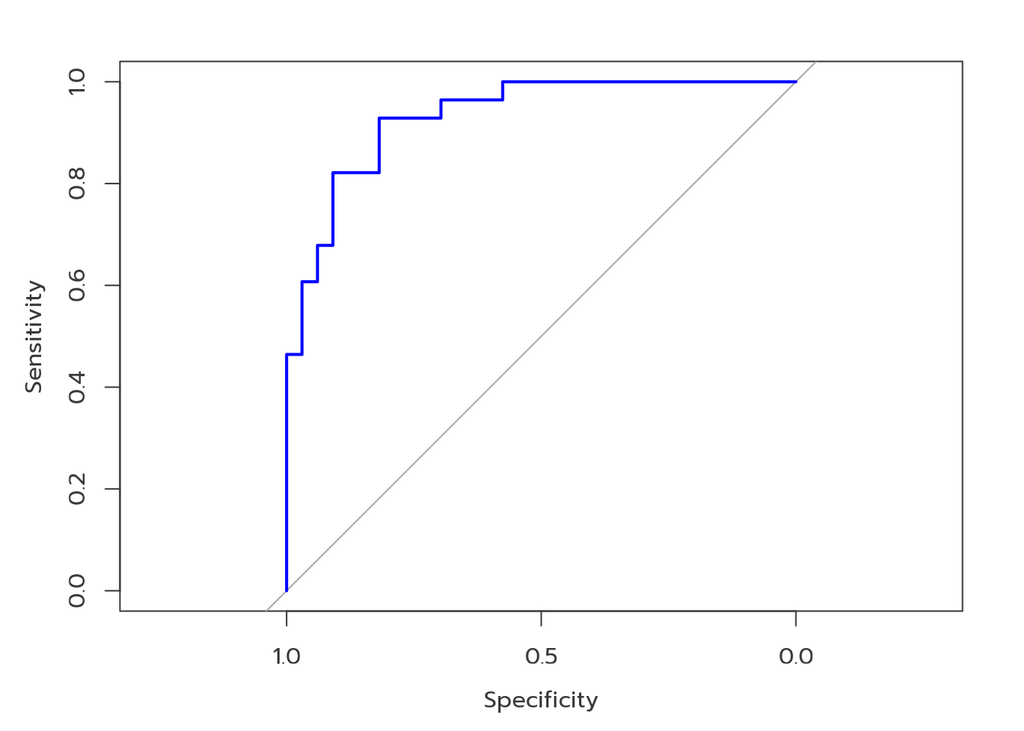

```r
# Create a ROC curve
ROC <- roc(test_set$output, predictions$base_prob)
# Plot the ROC curve
plot(ROC, col = "blue")
```

```r
# Calculate the area under the curve (AUC)
auc(ROC)
```

```
## Area under the curve: 0.9329
```

At the end of the first modeling round we achieved a model with 85% of accuracy and an AUC of 0.9329.

### Stepwise and cross-fold modeling

In this dataset we have a big problem, the data is small and for that reason we decide to perform a k-fold cross-validation of our model and on top of that a [stepwise modeling](https://www.statology.org/stepwise-regression-r/).

First we produce the k-folders. On this problem we will work with 5 folders.

```r
# Get the number of rows in heart_data
nRows <- nrow(heart_data)
# Implement the 3-fold cross-fold plan with vtreat
splitPlan <- kWayCrossValidation(nRows, 5, NULL, NULL)
# Examine the split plan
str(splitPlan)
```

```
## List of 5
##  $ :List of 2
##   ..$ train: int [1:243] 1 2 3 4 5 7 8 9 10 11 ...
##   ..$ app  : int [1:60] 80 93 84 109 236 66 160 126 218 52 ...
##  $ :List of 2
##   ..$ train: int [1:242] 1 4 6 7 8 9 10 11 12 13 ...
##   ..$ app  : int [1:61] 62 38 18 212 115 163 200 189 216 22 ...
##  $ :List of 2
##   ..$ train: int [1:242] 2 3 4 5 6 7 11 12 13 14 ...
##   ..$ app  : int [1:61] 303 56 233 265 177 168 134 205 290 96 ...
##  $ :List of 2
##   ..$ train: int [1:242] 1 2 3 4 5 6 7 8 9 10 ...
##   ..$ app  : int [1:61] 273 176 184 213 246 97 103 139 292 153 ...
##  $ :List of 2
##   ..$ train: int [1:243] 1 2 3 5 6 8 9 10 11 12 ...
##   ..$ app  : int [1:60] 165 208 278 232 40 47 196 127 4 302 ...
##  - attr(*, "splitmethod")= chr "kwaycross"
```

Now we will train our model for each folder and for last train a model with the whole dataset.

```r
# Run the 5-fold cross validation plan from splitPlan
prediction_coss_model <- 0
k <- 5 # Number of folds
predictions$prob.cv <- 0



# Tranning the k-folder stepwise stepmodel
for(i in 1:k) {
  split <- splitPlan[[i]]

  #creating a null model for each folder
  cross_null_model <- glm(output ~ 1, data = heart_data[split$train, ], family = binomial)
  #creating a full model for each folder
  cross_full_model <- glm(output ~ ., data = heart_data[split$train, ], family = binomial)
  #creating a stepwise model for each folder
  cross_step_model <- step(cross_null_model,
                           scope = list(lower = cross_null_model,
                                        upper = cross_full_model),
                           direction = "both")


  #Storing the probability for each folder
  predictions$prob.cv[split$app] <- predict(cross_step_model, newdata = ,heart_data[split$app, ],  type = "response")
  # Making prediction for each folder
  predictions$pred.cv[split$app] <- ifelse(predictions$prob.cv[split$app] > 0.5, 1, 0)
  # Calculating the accuracy for each folder of our model
  prediction_coss_model[i] <- mean(predictions$pred.cv[split$app]  == heart_data[split$app, ]$output)

}

# Now Lets model with the whole data.
# Creating a null model (stepwise model)
null_model <- glm(output ~ 1, data = heart_data, family = binomial)
# Creating a Full model
full_model <- glm(output ~ ., data = heart_data, family = binomial)
# Creating our Stepwise model
step_model <- step(null_model, scope = list(lower = null_model, upper = full_model), direction = "both")
```

Now we can see our final stepwise model

```r
#Summary of the final model
summary(step_model)
```

```
##
## Call:
## glm(formula = output ~ thall + caa + cp + oldpeak + slp + sex +
##     trtbps + exng, family = binomial, data = heart_data)
##
## Deviance Residuals:
##     Min       1Q   Median       3Q      Max
## -3.0264  -0.3305   0.1082   0.4577   2.9873
##
## Coefficients:
##             Estimate Std. Error z value Pr(>|z|)
## (Intercept)   1.2264     4.1252   0.297 0.766247
## thall1        2.6241     4.0772   0.644 0.519836
## thall2        2.3630     4.0122   0.589 0.555888
## thall3        0.9167     4.0144   0.228 0.819366
## caa1         -2.3551     0.4987  -4.723 2.33e-06 ***
## caa2         -3.1094     0.7536  -4.126 3.69e-05 ***
## caa3         -2.2676     0.9007  -2.518 0.011815 *
## caa4          1.2322     1.6218   0.760 0.447393
## cp1           1.0306     0.5647   1.825 0.068023 .
## cp2           2.2202     0.5171   4.293 1.76e-05 ***
## cp3           2.5594     0.7023   3.644 0.000268 ***
## oldpeak      -2.9741     1.4345  -2.073 0.038142 *
## slp1         -0.9067     0.8275  -1.096 0.273189
## slp2          0.7008     0.8968   0.781 0.434570
## sex1         -1.6315     0.5271  -3.095 0.001967 **
## trtbps       -2.3435     1.1583  -2.023 0.043051 *
## exng1        -0.8523     0.4366  -1.952 0.050925 .
## ---
## Signif. codes:  0 '***' 0.001 '**' 0.01 '*' 0.05 '.' 0.1 ' ' 1
##
## (Dispersion parameter for binomial family taken to be 1)
##
##     Null deviance: 417.64  on 302  degrees of freedom
## Residual deviance: 185.79  on 286  degrees of freedom
## AIC: 219.79
##
## Number of Fisher Scoring iterations: 6
```

#### Prediction and Accurary

First we will make predictions for our stepwise model

```r
# Calculating the probability of each output
predictions$step_prob <- predict(step_model, type = "response")
# Predict a heart attack if probability of output is greater than average
predictions$step_pred <- ifelse(predictions$step_prob > 0.5, 1, 0)
```

and now we can compare the Accuracy of the stepwise model with the mean accuracy of the 5 folders we produced.

```r
#Calculate the model's  partition accuracy
#mean(predictions$heart_pred.cv  == heart_data$output)

#Mean accuracy's prediction of the cross validation model 5 folders
print("Mean accuracy k-folder cross validation model")
```

```
## [1] "Mean accuracy k-folder cross validation model"
```

```r
mean(prediction_coss_model)
```

```
## [1] 0.8250273
```

```r
# Calculate the total model's accuracy
print("Accuracy stepwise model")
```

```
## [1] "Accuracy stepwise model"
```

```r
mean(predictions$step_pred  == heart_data$output)
```

```
## [1] 0.8910891
```

```r
#Confusion matrix cross validation model
print("Confusion matrix cross validation model")
```

```
## [1] "Confusion matrix cross validation model"
```

```r
table(predictions$pred.cv, heart_data$output)
```

```
##
##       0   1
##   0 107  22
##   1  31 143
```

```r
#Confusion matrix total model
print("Confusion matrix total model")
```

```
## [1] "Confusion matrix total model"
```

```r
caret::confusionMatrix(table(predictions$step_pred, heart_data$output))
```

```
## Confusion Matrix and Statistics
##
##
##       0   1
##   0 117  12
##   1  21 153
##
##                Accuracy : 0.8911
##                  95% CI : (0.8505, 0.9238)
##     No Information Rate : 0.5446
##     P-Value [Acc > NIR] : <2e-16
##
##                   Kappa : 0.7793
##
##  Mcnemar's Test P-Value : 0.1637
##
##             Sensitivity : 0.8478
##             Specificity : 0.9273
##          Pos Pred Value : 0.9070
##          Neg Pred Value : 0.8793
##              Prevalence : 0.4554
##          Detection Rate : 0.3861
##    Detection Prevalence : 0.4257
##       Balanced Accuracy : 0.8875
##
##        'Positive' Class : 0
##
```

And last the Roc curve of the stepwise model.

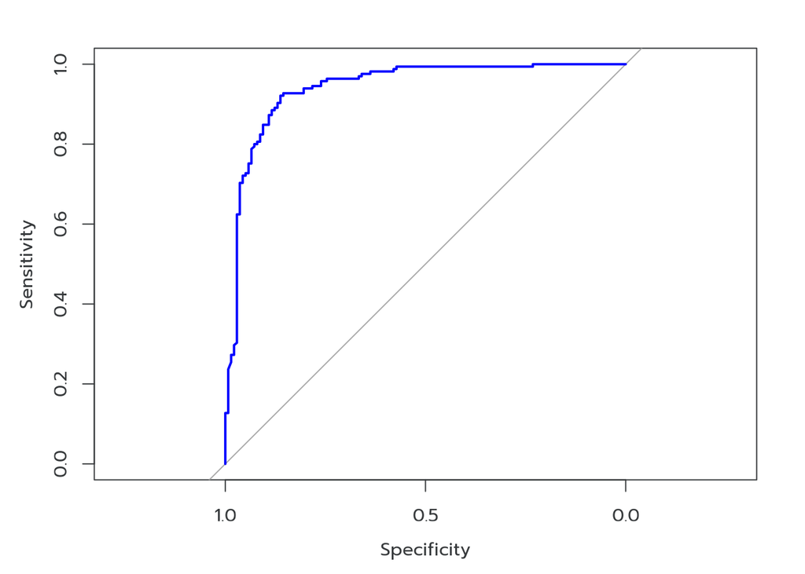

```r
# Create a ROC curve
ROC <- roc(heart_data$output, predictions$step_prob)
# Plot the ROC curve
plot(ROC, col = "blue")
```

```r
# Calculate the area under the curve (AUC)
auc(ROC)
```

```
## Area under the curve: 0.9419
```